# Technical Applications & Data Analytics (WS 2021)

Verschiedenen Algorithmen und Reflektion der Ergebnisse des Data Mining

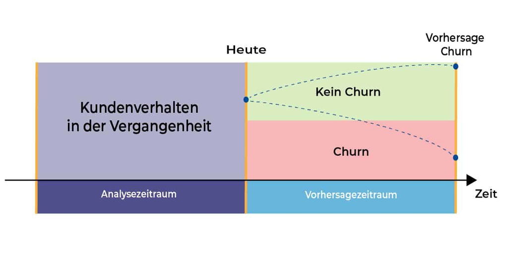

Abb. 3.g.1: Abwanderungsvorhersage

#### Data Mining Algorithmen

- **Lineare Regression**
- **Logistische Regression**
- **Entscheidungsbäume**
  - ID3, C4.5, CART, CHAID, MARS
- **Support Vector Maschine (SVM)**
- **Clustering Algorithmen**
  - K-Means, DB-Scan, Self Organized Maps, Hierarchisches Clustering
- **Random Forest**
- **Gradient Boosted Trees**
- **künstliche Neuronale Netze**
- **Recommernder System**
- **Assoziations Analysen**
  - Apriori Algorithmus, FPgrowth

### 3.g) Interpretation der Verschiedenen Algorithmen und Reflektion der Ergebnisse des Data Mining

#### Auswahl des passenden Algorithmus

- **Klassifikation**
  - z.B. Kundengewinnung
    - *Entscheidungsbaum* / *Decision tree* -> Reaktion von Kunden
- **Prognose**
  - z.B. Kundenwert eines Unternehmens (B2B)
    - *Text Mining (z.B. Webseite)* -> steigender Wert
- **Gruppierung**
  - z.B. Kundenverhalten
    - *Cluster Analyse (K-Means) -> Reaktion von Kunden
- **Assoziation**
  - z.B. Regeln unabhängig vom Kunden (ist evtl. nicht bekannt)
    - *Warenkorbanalyse* / *Basket Analysis* -> steigender Absatz

#### Text Mining

Text Mining befasst sich mit der Analyse von Textdokumenten. Texte sind im Gegensatz zu Datenbanken und Web-Seiten unstrukturiert. Texte genügen natürlich auch Strukturvorgaben wie einer Grammatik, […] letztendlich sind sie unstrukturiert.

[…] Da die Daten nur unstrukturiert vorliegen, ist der erste Schritt das Extrahieren der interessanten Informationen aus den Textdokumenten. Dies können beispielsweise Schlüsselwörter, die Häufigkeitsverteilung von Begriffen oder eine erste Kategorisierung oder hierarchische Gruppierung sein. Irrelevante Wörter (stop words) müssen herausgefiltert und Abkürzungen erkannt werden (Cleve & Lämmel, 2020).

### 3.h) Grundlagen des Web und Text Mining

#### Web Mining

Anwendungen des **Data Minings**, die das Internet als Datenquelle für die Mustererkennung heranziehen, werden unter dem Themengebiet des Web Minings zusammenge-fasst. In Abhängigkeit von der inhalts- oder nutzungsorientierten Analyse des World Wide Web (WWW) lassen sich die Teilgebiete **Web Content Mining**, **Web Structure Mining** und **Web Usage Mining** voneinander abgrenzen.

**Web Content Mining** befasst sich mit der Analyse von den im WWW befindlichen Daten. Dazu gehören textuelle und multimediale Informationen jeglichen Formats. […]

**Web Structure Mining** untersucht Links und Link-Strukturen. Dadurch können wichtige beziehungsweise populäre Seiten gefunden werden. […]

**Web Usage Mining** dagegen befasst sich mit dem Verhalten von Internet-Nutzern. Bei dieser Form des Web Mining werden Data-Mining-Methoden auf die Protokolldateien des Webservers angewandt, um Aufschlüsse über Verhaltensmuster und Interessen der Online-Nutzer zu erhalten. […]

## Erarbeiten IT-technischer Rahmenbedingungen

Erarbeiten IT-technischer Rahmenbedingungen:

- Anleitung / Installation der Open Source Lösung auf den Rechner der Studenten und Konfiguration von *Microsoft Excel (VBA)*
- Einführung und Anleitung der Applikation *R*
- Datenerfassung sowie das Einlesen der Beispieldaten zur ersten Analyse

### 4.a) Anleitung / Installation der Open Source Lösung auf den Rechner der Studenten und Konfiguration von *Microsoft Excel (VBA)***

#### Excel Datei mit Makro-Code (VBA) anpassen

- Entwicklertools aktivieren:
- auf der Registerkarte Datei **zu** Optionen -> **Menüband anpassen**
- **Menüband anpassen** und unter **Hauptregisterkarten** das Kontrollkästchen **Entwicklertools** aktivieren
- Erläuterung des Fragebogens
- Excel Datenblätter
- Fragebogen -> Maske zum erheben der Daten
- Daten -> Rohdaten des einzelnen Fragebogens
- Datenspeicherung -> Rohdaten aller Fragenbögen -> Speicherung in CSV-Datei oder XML-Datei möglich
- VBA Code -> auf Menüband auf **Entwicklertools** und links auf

**Visual Basic** klicken und die entsprechenden Elemente anpassen

**Installation der (Text-)Editoren Windows** Für das Microsoft Windows Betriebssystem hat sich der kostenlose Editor *Notepad++* in Funktionsumfang, Performance und Anwenderfreundlichkeit einen deutlichen Vorsprung gegenüber der Konkurrenz erarbeitet. *Notepadd++* herunterladen unter:https://notepad-plus-plus.org/downloads/

#### MacOS

Für das Apple MacOS Betriebssystem kann man sehr gut auf den kostenlosen Editor *Brackets* von Adobe zurückgreifen. *Brackets* herunterladen unter: https://brackets.de.uptodown.com/macUnterhttps://registry.brackets.io lassen sich eine Vielzahl an Erweiterungen downloaden und unter *Datei – Erweiterungsverwaltung* installieren. Für die Vorlesung sind wichtig:

- *Beautifiy* (Code formatter, z.B. XML-Struktur)
- *Documents-Toolbar* (Toolbar mit Tabs)
- *BracketstoIX* (Top menu IX mit vielen Funktionen)
- *Excel to Table* (Excel Tabellen in Brackets einfügen)
- *Newline* (konvertiert den Zeilenumbruch LF (Mac / Linux) <–> CRLF (Windows))

#### iPadOS

Für das Apple iPad kann der Editor *Kodex* über den Apple App Store installiert werden.

**4. Erarbeiten IT-technischer Rahmenbedingungen 4.a) Anleitung / Installation der Open Source Lösung auf den Rechner der Studenten und Konfiguration von *Microsoft Excel (VBA)***

#### Installation von *R*

*R* herunterladen unter[: https://cran.r-project.org/bin/macosx/](https://cran.r-project.org/bin/macosx/)(MacOS) oder https://cran.r-project.org/bin/windows/base/(Windows)

#### Inhalte und Anwendungsgebiet

In dem Installations-Paket sind alle notwendigen Basisfunktionen enthalten [(*base-package*) siehe https://stat.ethz.ch/R-manual/R- devel/library/base/html/00Index.html.](https://stat.ethz.ch/R-manual/R-devel/library/base/html/00Index.html)

*R* ist eine vollständige, **objekt-orientierte Programmiersprache** und kann vielfältige Operationen mit einer eigenen Syntax ausführen. Häufig wird *R* zur statistischen Datenverarbeitung eingesetzt.

Im *Comprehensive R Archive Network* (kurz: *CRAN*), einem Netz aus Webservern, werden über 2000 Funktionserweiterungen, Datensätze und Code in Form von Paketen bereitgestellt.

**4. Erarbeiten IT-technischer Rahmenbedingungen 4.a) Anleitung / Installation der Open Source Lösung auf den Rechner der Studenten und Konfiguration von *Microsoft Excel (VBA)***

#### *R* auf dem *iPad* (oder *iPhone*) installieren

Auf dem *iPad* im App Store *TestFlight* installieren. Dann mittels des Links die aktuelle Beta  
von *iSH-AOK* installieren: https://testflight.apple.com/join/X1flyiqE

Um *R* auf dem *iPad* sinnvoll nutzen zu können, kann die *Dateien* App in den **Splitscreen** an den Bildschirmrand hinzugefügt werden.

In der Dateien App muss vorher das **Laufwerk** *ish* **aktiviert** werden. Die Ausgabe-Dateien liegen unter ish `/home/ish/R/`

Nach der Ausgabe eines Diagrammes zum **Aktualisieren** des Ordnerinhaltes einmal  
zurück und wieder rein gehen.

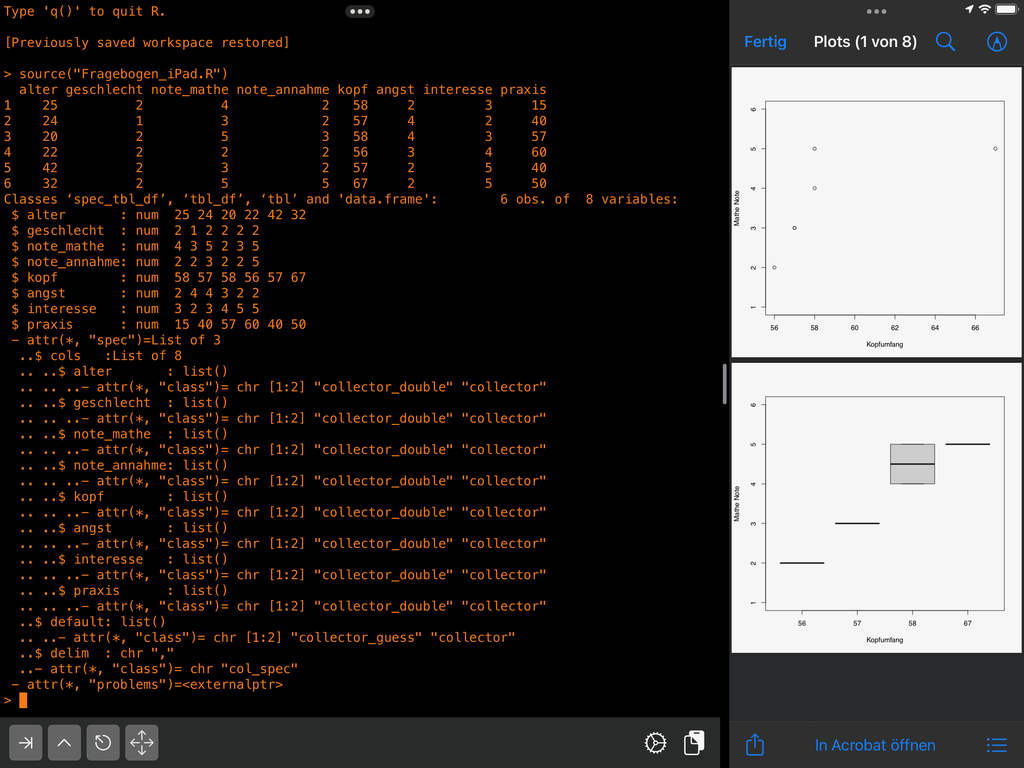

Abb. 4.a.1: *R* auf *iPad* mit *Dateien* App im Splitscreen

#### *R Studio* und *Xquartz* installieren

*RStudio* herunterladen unter (*R* muss vorher installiert sein): [https://www.rstudio.com/products/rstudio/download/#download](https://www.rstudio.com/products/rstudio/download/)(Windows / MacOS)

*XQuartz* herunterladen unter: https://www.xquartz.org(MacOS)

Unter *RStudio* lassen sich komplexe Skripte ausführen, das Paketmanagement ist vereinfacht sowie ist die grafische Ausgabe möglich.

*XQuartz* bietet unter *MacOS* eine X.Org (X Window System) Version. X.Org ist unter Linux / Unix die grafische Benutzeroberfläche.

[figure not shown]

Abb. 4.a.2: *R-Studio*

### 4.b) Einführung und Anleitung der Applikation *R*

**Erste Schritte mit *R* Grundsätzliches**

- R unterscheidet zwischen Groß- und Kleinschreibung, d.h. *Oma* und *oma* sind verschiedene Wesen
- R verwendet den . (Punkt) als Dezimaltrennzeichen
- Fehlende Werte werden in R durch *NA* gekennzeichnet
- Kommentare (nicht auszuführender Code) werden mit dem # (Hashtag) eingeleitet
- Variablennamen sollten mit Buchstaben beginnen, sowie können sie Zahlen und _ enthalten
- Um den Inhalt einer Variablen auszulesen, geben wir einfach den Namen an
- Text muss in ““ oder ‘‘ (doppelte oder einfache Anführungszeichen) gesetzt werden

#### R Code

```r
# Kommentare / nicht ausführbarer Code werden mit der Raute bzw. hashtag eingeleitet
temperatur <- -10

# der Variablen temperatur den Wert -10 zuweisen
print(temperatur)

# Variable temperatur ausgeben
text <- "Dies ist ein Text"

# Text einer Variablen zuweisen
print(text)

# Variable text ausgeben
print(text)

# Variable einer anderen zuweisen

text <- temperatur
```

### 4.b) Einführung und Anleitung der Applikation *R*

#### Einführung in *R*

```r
# Funktionen ausführen
help(c)

# Hilfe für Funktion c aufrufen, Alternativ ?c
temperatur <- c(18, 22, 23, 24)
# Funktion c: fasst Werte in einer Liste zusammen

# ineinander verschachtelte Funktionen
temperatur <- c(18, 22, as.integer(runif(1, -12, 40)), 24)

# Variable mit dem Mittelwert aus temperatur füllen
ein_mittelwert <- mean(temperatur)

# 2 weitere mögliche Schreibweisen
ein_mittelwert <- mean(x = temperatur, trim = 0, na.rm = FALSE)
ein_mittelwert <- mean(temperatur, 0, FALSE)

# Logische Prüfungen
2 < 3 # Kleiner-Prüfung
2 > 3 # Größer-Prüfung
2 <= 3 # Kleiner-Gleich-Prüfung
2 >= 3 # Größer-Gleich-Prüfung
2 == 3 # Prüfung auf Gleichheit
2 != 3 # Prüfung auf Ungleichheit

temperatur < 8 & temperatur > -12 # & verknüpft Bedingungen
temperatur < 8 | temperatur > 0 # | oder Statement
```

#### Einführung in *R* – Diagramme (Datei *Diagramme.R* auf Ilias)

```r
# Library ourdata laden
library(ourdata)

# Balken-Diagramm, veranschaulicht die Verbindung zwischen einer
# numerischen und einer kategorialen Variablen. Das Balkendiagramm
# stellt jede Kategorie als Balken dar und spiegelt den entsprechenden
# numerischen Wert mit der Größe des Balkens wider.
barplot(koelsch$Koelsch)

# Streu-Diagramm, zeigt zwei numerische Variablen mit Punkten an,
# wobei jeder Punkt den Wert einer Variablen auf der x-Achse und den
# Wert der anderen Variablen auf der y-Achse darstellt.
plot(kirche$Austritte ~ koelsch$Koelsch)

# Boxplot-Diagramm, zeigt die Verteilung einer numerischen Variablen
# basierend auf fünf zusammenfassenden Statistiken: minimaler
# Nicht-Ausreißer; erstes Quartil; Median; drittes Quartil; und maximaler
# Nicht-Ausreißer. Außerdem zeigen Boxplots die Positionierung von
# Ausreißern und ob die Daten verzerrt sind.
boxplot(koelsch$Koelsch)
```

#### Einführung in *R* – Diagramme (Datei *Diagramme.R* auf Ilias)

```r
# Dichte-Diagramm, zeigt die Verteilung einer numerischen Variablen
# über ein kontinuierliches Intervall. Peaks eines Dichte-Diagramms
# visualisieren, wo sich die Werte numerischer Variablen konzentrieren.
plot(density(koelsch$Koelsch))
# Heatmap-Diagramm, visualisiert einzelne Werte einer Matrix mit Farben.
# Häufigere Werte werden typischerweise durch hellere rötliche Farben
# angezeigt und weniger häufige Werte werden typischerweise durch
# dunklere Farben angezeigt.
heatmap(cbind(fragebogen$alter, fragebogen$praxis))

# Linien-Diagramm, visualisiert Werte entlang einer Sequenz
(z.B. über die Zeit). Liniendiagramme bestehen aus einer x-Achse
# und einer y-Achse. Die x-Achse zeigt normalerweise die Sequenz
# und die y-Achse die Werte an, die jedem Punkt der Sequenz entsprechen.
plot(1:length(fragebogen$alter), fragebogen$alter, type = "l")
```